# Anàlisi de l’índex de pobresa temporal Catalunya · 2011

Aniol Vilamala Vidal

Estadístic

Marina Callejero González

Investigadora

25 de octubre de 2026

# 1 0 Llibreries, constants i funcions auxiliars

Les llibreries s’haurien de citar a les referències del TFG amb `citation("llibreria")`.

```r
library(DT)
library(rstatix)
library(compareGroups)
library(glmmTMB)
library(broom.mixed)
library(sjPlot)
library(DHARMa)
library(performance)
library(ggstatsplot)
library(tidyverse)

select <- dplyr::select
dir.create("sortides", showWarnings = FALSE)

us_temps <- c("Temps disponible", "Cures personals", "Estudi",
              "Treball remunerat", "Treball no remunerat")

colors_ipt <- c("#95D0EA", "#9ACD32")
```

```r
etiqueta_p <- function(p, digits = 3) {
  ifelse(p < 0.01, "p < 0.01", paste0("p = ", signif(p, digits)))
}

tema_tfg <- function(base_size = 14, angle = 0) {
  theme_minimal(base_size = base_size) +
    theme(
      panel.grid = element_blank(),
      axis.line = element_line(color = "black"),
      axis.ticks = element_line(color = "black"),
      axis.title = element_text(face = "bold"),
      axis.text.x = element_text(angle = angle, hjust = ifelse(angle > 0, 1, 0.5)),
      plot.title = element_text(face = "bold"),
      plot.title.position = "plot",
      plot.margin = margin(10, 20, 10, 20)
    )
}

mostra <- function(g, nom, w = 8, h = 7) {
  ggsave(file.path("sortides", paste0(nom, ".png")), g, width = w, height = h)
  g
}

# ---------- IPT segons una variable categòrica ----------

resum_ipt <- function(dades, var) {
  dades %>%
    filter(!is.na(.data[[var]])) %>%
    group_by(Grup = .data[[var]]) %>%
    summarise(N = n(), Pobres = sum(IPT_FACTOR == "Pobre"), .groups = "drop") %>%
    mutate(
      `% pobres` = round(Pobres / N * 100, 1),
      `IC 95%` = map2_chr(Pobres, N, ~ {
        ci <- binom.test(.x, .y)$conf.int * 100
        sprintf("[%.1f, %.1f]", ci[1], ci[2])
      })
    )
}

chi_ipt <- function(dades, var) {
  chisq.test(table(droplevels(dades[[var]]), dades$IPT_FACTOR))
}

interpreta_chi <- function(dades, var) {
  p <- chi_ipt(dades, var)$p.value
  paste0(
    "El test χ² d'independència dóna ", etiqueta_p(p), ": ",
    ifelse(p < 0.05,
           "hi ha evidència d'una associació estadísticament significativa entre la variable i la pobresa temporal.",
           "no s'observa una associació estadísticament significativa entre la variable i la pobresa temporal.")
  )
}

pairwise_ipt <- function(dades, var) {
  mat <- table(droplevels(dades[[var]]), dades$IPT_FACTOR)
  pw <- pairwise.prop.test(x = mat[, "Pobre"], n = rowSums(mat),
                           p.adjust.method = "holm")
  as.data.frame(pw$p.value) %>%
    rownames_to_column("grup1") %>%
    pivot_longer(-grup1, names_to = "grup2", values_to = "p") %>%
    filter(!is.na(p)) %>%
    transmute(Comparació = paste(grup1, "vs", grup2),
              `p-valor ajustat (Holm)` = etiqueta_p(p))
}

plot_ipt <- function(dades, var, titol, xlab, angle = 0) {
  test <- chi_ipt(dades, var)
  dades %>%
    filter(!is.na(.data[[var]])) %>%
    count(grup = .data[[var]], IPT_FACTOR) %>%
    group_by(grup) %>%
    mutate(percent = n / sum(n) * 100) %>%
    ungroup() %>%
    ggplot(aes(x = grup, y = percent, fill = IPT_FACTOR)) +
    geom_col(color = "black", width = 0.7) +
    geom_text(aes(label = paste0(round(percent, 1), "%")),
              position = position_stack(vjust = 0.5), size = 4) +
    scale_fill_manual(values = colors_ipt) +
    scale_y_continuous(limits = c(0, 100), breaks = seq(0, 100, 25),
                       expand = expansion(mult = c(0, 0.08))) +
    labs(title = titol,
         subtitle = paste0("Test χ² d'independència (", etiqueta_p(test$p.value), ")"),
         x = xlab, y = "Percentatge", fill = "IPT") +
    tema_tfg(angle = angle)
}

# ---------- Ús del temps ----------

taula_us_temps <- function(dades, var, caption) {
  formula <- as.formula(paste(var, "~", paste0("`", us_temps, "`", collapse = " + ")))
  res <- compareGroups(formula, data = dades)
  export2md(createTable(res, show.all = TRUE, show.ci = TRUE),
            format = "html", background = "#D2D2D2", header.color = "black",
            caption = caption, size = 15)
}

plot_us_temps <- function(dades, var, titol, etiqueta, facet = NULL, angle = 30) {
  dades <- dades %>% filter(!is.na(.data[[var]]))

  proves <- dades %>%
    group_by(across(all_of(c(facet, "US_TEMPS")))) %>%
    rstatix::wilcox_test(as.formula(paste("HORES ~", var))) %>%
    adjust_pvalue(method = "holm") %>%
    mutate(p_label = etiqueta_p(p.adj, 2), y = max(dades$HORES) * 1.1)

  g <- ggplot(dades, aes(x = US_TEMPS, y = HORES, fill = .data[[var]])) +
    geom_violin(trim = FALSE, position = position_dodge(width = 0.55),
                alpha = 0.45, color = NA, scale = "width", width = 0.5) +
    geom_boxplot(width = 0.3, position = position_dodge(width = 0.55),
                 outlier.shape = NA, alpha = 0.9, color = "black", linewidth = 0.5) +
    geom_text(data = proves, aes(x = US_TEMPS, y = y, label = p_label),
              inherit.aes = FALSE, size = 3.8) +
    scale_fill_manual(values = colors_ipt) +
    labs(title = titol, subtitle = "Test de Wilcoxon amb p-valors ajustats segons Holm",
         x = "Ús del temps", y = "Hores diàries", fill = etiqueta) +
    tema_tfg(angle = angle)

  if (!is.null(facet)) g <- g + facet_wrap(facet)
  g
}

plot_mitjanes <- function(dades, var, titol, etiqueta, facet = NULL, angle = 30) {
  g <- dades %>%
    filter(!is.na(.data[[var]])) %>%
    group_by(across(all_of(c(facet, "US_TEMPS"))), grup = .data[[var]]) %>%
    summarise(mitjana = mean(HORES), se = sd(HORES) / sqrt(n()), .groups = "drop") %>%
    ggplot(aes(x = US_TEMPS, y = mitjana, fill = grup)) +
    geom_col(position = position_dodge(width = 0.8), width = 0.7) +
    geom_errorbar(aes(ymin = mitjana - 1.96 * se, ymax = mitjana + 1.96 * se),
                  position = position_dodge(width = 0.8), width = 0.2) +
    scale_fill_manual(values = colors_ipt) +
    labs(title = titol, subtitle = "Mitjana i interval de confiança al 95%",
         x = "Ús del temps", y = "Mitjana d'hores", fill = etiqueta) +
    tema_tfg(angle = angle)

  if (!is.null(facet)) g <- g + facet_wrap(facet)
  g
}

plots_us_temps_grups <- function(dades, var, etiqueta, angle = 45) {
  dades <- dades %>% filter(!is.na(.data[[var]]))
  map(levels(dades$US_TEMPS), function(ut) {
    dades %>%
      filter(US_TEMPS == ut) %>%
      ggbetweenstats(
        x = !!rlang::sym(var), y = HORES,
        type = "nonparametric", p.adjust.method = "holm",
        results.subtitle = FALSE, bf.message = FALSE,
        title = paste0(ut, " segons ", etiqueta, " (2011)"),
        xlab = etiqueta, ylab = "Hores diàries",
        ggplot.component = list(theme(axis.text.x = element_text(angle = angle, hjust = 1)))
      )
  })
}
```

# 2 1 Generació de les bases de dades

## 2.1 1.1 Importació

```r
library(readr)
library(dplyr)

llegeix <- function(fitxer) {
  read_delim(
    fitxer,
    delim = "\t",
    escape_double = FALSE,
    trim_ws = TRUE,
    show_col_types = FALSE
  )
}

# Crear la carpeta si no existeix
dir.create("dta", showWarnings = FALSE, recursive = TRUE)

# 1. Llars
dades_llar <- llegeix("eut2011l.data.csv") %>%
  mutate(CODI_LLAR = sprintf("%04d", CODI_LLAR))

saveRDS(dades_llar, "dta/dades_llar_2011.rds")

# 2. Individuals
dades_indiv <- llegeix("eut2011i.data.csv") %>%
  mutate(across(c(CODI_LLAR, CODI_PERSONA), as.character))

saveRDS(dades_indiv, "dta/dades_indiv_2011.rds")

# 3. Temps
dades_temps <- llegeix("eut2011d.data.csv") %>%
  mutate(
    CODI_LLAR = sprintf("%04d", CODI_LLAR),
    CODI_PERSONA = sprintf("%02d", CODI_PERSONA)
  )

saveRDS(dades_temps, "dta/dades_temps_2011.rds")
```

```r
dades_llar  <- readRDS("dta/dades_llar_2011.rds")
dades_indiv <- readRDS("dta/dades_indiv_2011.rds")
dades_temps <- readRDS("dta/dades_temps_2011.rds")
```

## 2.2 1.2 Base individual, hores per categoria i IPT

```r
dades_base <- dades_indiv %>%
  left_join(dades_llar, by = "CODI_LLAR") %>%
  left_join(dades_temps, by = c("CODI_LLAR", "CODI_PERSONA")) %>%
  rename(IDLLAR = CODI_LLAR, IDPERSONA = CODI_PERSONA)

dades_base <- dades_base %>%
  mutate(
    treball_rem = (trebprin + desplaç_treb + altretreb) / 3600,
    treball_no_rem = (culin + llarfam_ne + mantllar + confecc + jardi + repar +
                        compra + gestio + curanen + curadul + organit + altllar +
                        desplaç_llarfam + desplaç_vol) / 3600,
    estudis = (estudis_ne + estudis + estudis_tll + desplaç_est) / 3600,
    higiene = (dormir + menjar + altrecur) / 3600,
    hores_lliures = 24 - treball_rem - treball_no_rem - estudis - higiene
  )

n_inicial <- nrow(dades_base)

dades_base <- dades_base %>% filter(!is.na(hores_lliures))

n_final <- nrow(dades_base)

ipt_fgt <- function(temps, llindar = 0.5, alpha = 0) {
  z <- llindar * median(temps, na.rm = TRUE)
  time_poor <- ifelse(temps < z, 1, 0)

  if (alpha == 0) {
    fgt_value <- mean(time_poor)
  } else {
    gaps <- ifelse(time_poor == 1, (z - temps) / z, 0)
    fgt_value <- mean(gaps^alpha)
  }

  list(index = fgt_value, llindar = z, pob_temps = time_poor)
}

res_ipt <- ipt_fgt(dades_base$hores_lliures)
llindar_ipt <- res_ipt$llindar
```

## 2.3 1.3 Indicadors de voluntariat i ajuda, i recodificació

```r
vars_vol <- paste0("T5_VOLUNTARIAT", setdiff(1:12, 6))

vars_aj <- c("T5_VOLUNTARIAT6", paste0("T4_AJ_ALTRES", 1:10))

dades_base <- dades_base %>%
  mutate(
    VOL_TOTAL = rowSums(across(all_of(vars_vol)) == 1, na.rm = TRUE),
    AJ_TOTAL  = rowSums(across(all_of(vars_aj)) == 1, na.rm = TRUE),
    IPT       = res_ipt$pob_temps,

    SEXE = factor(Sexe, levels = c(6, 1), labels = c("Dona", "Home")),

    TRAM_EDAT = cut(Edat, breaks = c(10, 25, 45, 65, Inf), right = FALSE,
                    labels = c("10-24", "25-44", "45-64", "65+")),

    AD_DEP = factor(T5_AD_DEP, levels = c(6, 1), labels = c("No", "Si")),

    TIPUS_DIA = factor(T7_TIPUS_DIA, levels = 1:2,
                       labels = c("Dia normal", "Dia inusual")),

    TIPUS_LLAR = factor(
      T5_TIPUS_LLAR, levels = c(3, 7, 1, 2, 5, 8, 6, 4, 9),
      labels = c("Parella amb fills <25", "Parella amb fills <25",
                 "Unipersonal", "Parella sense fills",
                 "Monoparental fills <25", "Monoparental fills <25",
                 "Monoparental fills ≥25", "Parella amb fills ≥25", "Altres")
    ),

    DEGURBA = factor(DIM_MUN, levels = 1:3,
                     labels = c("-20.000 habitants", "20.000-100.000 habitants",
                                "+100.000 habitants")),

    NAC = factor(T6_NACIONALITAT, levels = 1:4,
                 labels = c("Espanyola", "Estrangera", "Estrangera", "Estrangera")),

    ESTAT_CIVIL = factor(T6_ESTAT_CIVIL, levels = 1:4,
                         labels = c("Solter/a", "Casat/ada", "Vidu/a", "Divorciat/ada")),

    ESTUDI_ALT = factor(
      T6_ESTUDI_ALT, levels = 1:9,
      labels = c("Primaria o inferior", "Primaria o inferior", "Primaria o inferior",
                 "Secundaria 1a etapa",
                 "Secundaria 2a etapa", "Secundaria 2a etapa", "Secundaria 2a etapa",
                 "Superior", "Superior")
    ),

    REL_ACT = factor(T3_SITUACIO_ACTIV, levels = 1:4,
                     labels = c("Ocupat", "Aturat", "Jubilat", "Inactiu")),

    TRAM_INGRESSOS = factor(
      T5_INGRESSOS, levels = 1:10,
      labels = c("700 € o menys", "De 701 € a 1.000 €", "De 1.001 € a 1.400 €",
                 "De 1.401 € a 1.700 €", "De 1.701 € a 2.000 €",
                 "De 2.001 € a 2.300 €", "De 2.301 € a 2.600 €",
                 "De 2.601 € a 3.100 €", "De 3.101 € a 4.000 €", "Més de 4.000 €")
    ),

    TRAM_INGRESSOS_REDUIT = factor(
      T5_INGRESSOS, levels = 1:10,
      labels = c("700 € o menys",
                 "De 701 € a 1.400 €", "De 701 € a 1.400 €",
                 "De 1.401 € a 2.000 €", "De 1.401 € a 2.000 €",
                 "De 2.001 € a 2.600 €", "De 2.001 € a 2.600 €",
                 "Més de 2.600 €", "Més de 2.600 €", "Més de 2.600 €")
    )
  ) %>%
  rename(NUM_MEMBRES = T5_NUM_MEMBRES)
```

## 2.4 1.4 Bases de dades finals

### 2.4.1 1.4.1 `dades_models_2011`

```r
dades_models_2011 <- dades_base %>%
  select(
    IDLLAR, IDPERSONA, IPT,
    SEXE, TRAM_EDAT, AD_DEP, TIPUS_LLAR, TIPUS_DIA, DEGURBA, NUM_MEMBRES,
    NAC, ESTAT_CIVIL, ESTUDI_ALT, REL_ACT, TRAM_INGRESSOS, TRAM_INGRESSOS_REDUIT,
    AJ_TOTAL, VOL_TOTAL
  )
```

### 2.4.2 1.4.2 `dades_wide_2011`

```r
dades_wide_2011 <- dades_base %>%
  transmute(
    IDLLAR, IDPERSONA,
    IPT_FACTOR = factor(IPT, levels = c(0, 1), labels = c("No pobre", "Pobre")),
    `Temps disponible`     = hores_lliures,
    `Cures personals`      = higiene,
    `Estudi`               = estudis,
    `Treball remunerat`    = treball_rem,
    `Treball no remunerat` = treball_no_rem,
    SEXE, TRAM_EDAT, DEGURBA, NAC, TIPUS_LLAR, ESTUDI_ALT,
    TRAM_INGRESSOS, TRAM_INGRESSOS_REDUIT
  )
```

### 2.4.3 1.4.3 `dades_long_2011`

```r
dades_long_2011 <- dades_wide_2011 %>%
  pivot_longer(cols = all_of(us_temps), names_to = "US_TEMPS", values_to = "HORES") %>%
  mutate(US_TEMPS = factor(US_TEMPS, levels = us_temps))
```

```r
rm(dades_llar, dades_indiv, dades_temps, dades_base)

tibble(
  Base = c("dades_models_2011", "dades_wide_2011", "dades_long_2011"),
  Files = c(nrow(dades_models_2011), nrow(dades_wide_2011), nrow(dades_long_2011)),
  Columnes = c(ncol(dades_models_2011), ncol(dades_wide_2011), ncol(dades_long_2011))
) %>%
  knitr::kable(caption = "Bases de dades finals")
```

Bases de dades finals

| Base | Files | Columnes |
| --- | --- | --- |
| dades_models_2011 | 6471 | 18 |
| dades_wide_2011 | 6471 | 16 |
| dades_long_2011 | 32355 | 13 |

# 3 2 Índex de Pobresa Temporal (IPT)

## 3.1 2.1 Definició

La metodologia habitual per mesurar la pobresa de temps segueix la proposta de Foster, Greer i Thorbecke (1984), tal com l’apliquen Vega-Rapun, Domínguez-Serrano i Gálvez-Muñoz (*The multidimensionality of poverty: Time poverty in Spain*):

$$FGT_\alpha = \frac{1}{N} \sum_{i=1}^{q} \left( \frac{z - y_i}{z}
\right)^\alpha$$

on $z$ és el llindar de pobresa de temps, $N$ la població total, $q$ el nombre de persones pobres en temps, $y_i$ el temps disponible de l’individu $i$ i $\alpha$ el paràmetre d’aversió a la pobresa:

```r
tibble(
  `Valor d'α` = 0:2,
  `Nom de la mesura` = c("Headcount index", "Poverty gap", "Severity index"),
  Interpretació = c(
    "Proporció d'individus amb temps disponible inferior al llindar.",
    "Intensitat mitjana de la pobresa: quant falta, proporcionalment, per arribar al llindar.",
    "Penalitza més les situacions de pobresa extrema; mesura la desigualtat entre els pobres."
  )
) %>%
  knitr::kable()
```

| Valor d’α | Nom de la mesura | Interpretació |
| --- | --- | --- |
| 0 | Headcount index | Proporció d’individus amb temps disponible inferior al llindar. |
| 1 | Poverty gap | Intensitat mitjana de la pobresa: quant falta, proporcionalment, per arribar al llindar. |
| 2 | Severity index | Penalitza més les situacions de pobresa extrema; mesura la desigualtat entre els pobres. |

Aquest treball utilitza el *headcount index* ($\alpha = 0$) amb el llindar $z$ fixat com el 50% de la mediana del temps disponible:

$$H = \frac{q}{N}$$

Així, cada persona és pobra en temps (1) o no (0). Aquest indicador és l’**Índex de Pobresa Temporal (IPT)**. La funció `ipt_fgt()` permet calcular també la resta d’índexs FGT.

El llindar de pobresa temporal és de **2.58 hores** diàries de temps disponible: les persones per sota d’aquest valor es classifiquen com a pobres en temps. La mostra d’anàlisi té **6471 individus** (se n’han eliminat 0 per no disposar de diari d’activitats) i el **22.36%** presenta pobresa temporal.

```r
resum_ipt(dades_wide_2011 %>% mutate(Total = factor("Total")), "Total") %>%
  knitr::kable(caption = "Prevalença global de pobresa temporal (2011)")
```

Prevalença global de pobresa temporal (2011)

| Grup | N | Pobres | % pobres | IC 95% |
| --- | --- | --- | --- | --- |
| Total | 6471 | 1447 | 22.4 | [21.4, 23.4] |

## 3.2 2.2 Variables d’estudi

```r
tibble(
  Variable = c("DEGURBA", "TIPUS_LLAR", "TIPUS_DIA", "NUM_MEMBRES", "AD_DEP", "NAC",
               "ESTAT_CIVIL", "ESTUDI_ALT", "TRAM_EDAT", "SEXE", "REL_ACT",
               "TRAM_INGRESSOS", "TRAM_INGRESSOS_REDUIT", "AJ_TOTAL", "VOL_TOTAL"),
  Descripció = c(
    "Mida del municipi (`DIM_MUN`; a la BD del 2024 és el grau d'urbanització)",
    "Composició de la llar (categories harmonitzades amb el 2024)",
    "Dia atípic o normal", "Nombre de membres de la llar",
    "Adults en situació de dependència a la llar", "Nacionalitat",
    "Estat civil legal", "Estudi de més alt nivell assolit (agrupat en 4 nivells)",
    "Tram d'edat", "Sexe", "Relació amb l'activitat econòmica",
    "Tram d'ingressos mensuals de la llar (10 trams)",
    "Tram d'ingressos agrupat en 5 trams",
    "Nombre d'àmbits en què la persona ha ajudat (voluntariat d'assistència i ajudes a altres llars)",
    "Nombre de tipus de voluntariat realitzats"
  )
) %>%
  knitr::kable(caption = "Variables considerades")
```

Variables considerades

| Variable | Descripció |
| --- | --- |
| DEGURBA | Mida del municipi (`DIM_MUN`; a la BD del 2024 és el grau d’urbanització) |
| TIPUS_LLAR | Composició de la llar (categories harmonitzades amb el 2024) |
| TIPUS_DIA | Dia atípic o normal |
| NUM_MEMBRES | Nombre de membres de la llar |
| AD_DEP | Adults en situació de dependència a la llar |
| NAC | Nacionalitat |
| ESTAT_CIVIL | Estat civil legal |
| ESTUDI_ALT | Estudi de més alt nivell assolit (agrupat en 4 nivells) |
| TRAM_EDAT | Tram d’edat |
| SEXE | Sexe |
| REL_ACT | Relació amb l’activitat econòmica |
| TRAM_INGRESSOS | Tram d’ingressos mensuals de la llar (10 trams) |
| TRAM_INGRESSOS_REDUIT | Tram d’ingressos agrupat en 5 trams |
| AJ_TOTAL | Nombre d’àmbits en què la persona ha ajudat (voluntariat d’assistència i ajudes a altres llars) |
| VOL_TOTAL | Nombre de tipus de voluntariat realitzats |

# 4 3 Anàlisi exploratòria de dades (AED)

## 4.1 3.0 Proves i tests estadístics utilitzats

#### 4.1.0.1 **0. Les hores d’ús del temps segueixen una distribució normal?**

Si els punts del Q-Q plot s’allunyen molt de la línia, la variable no és normal.

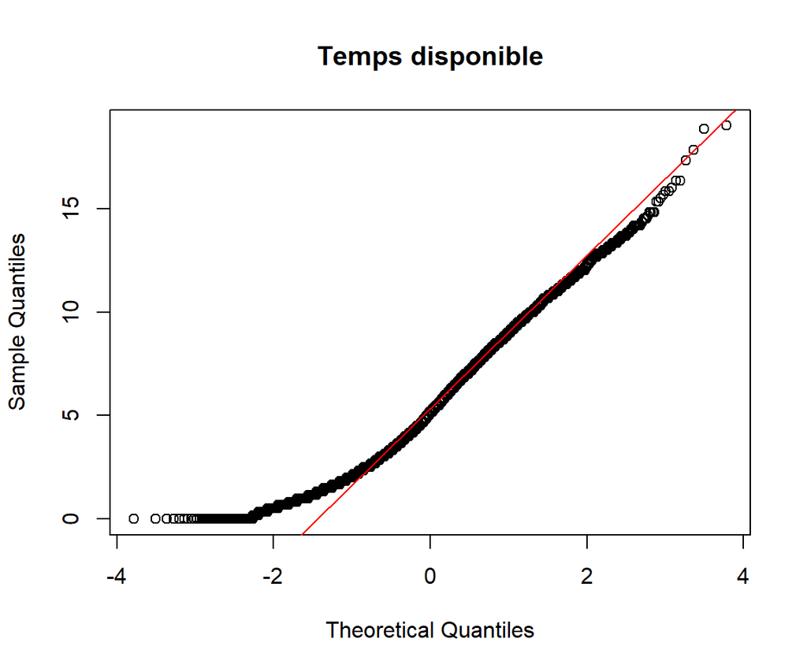

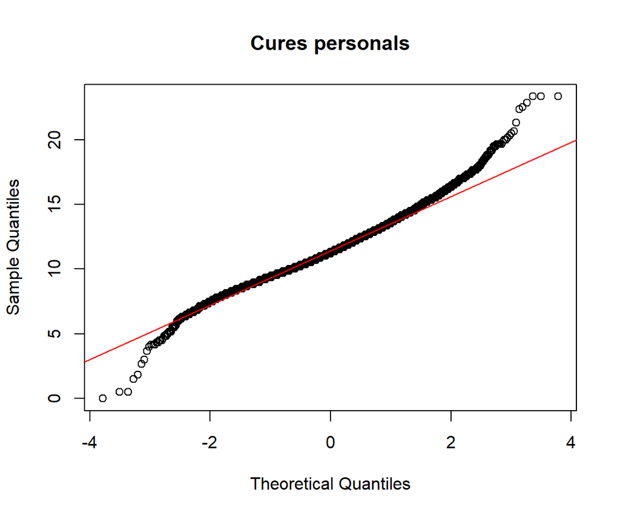

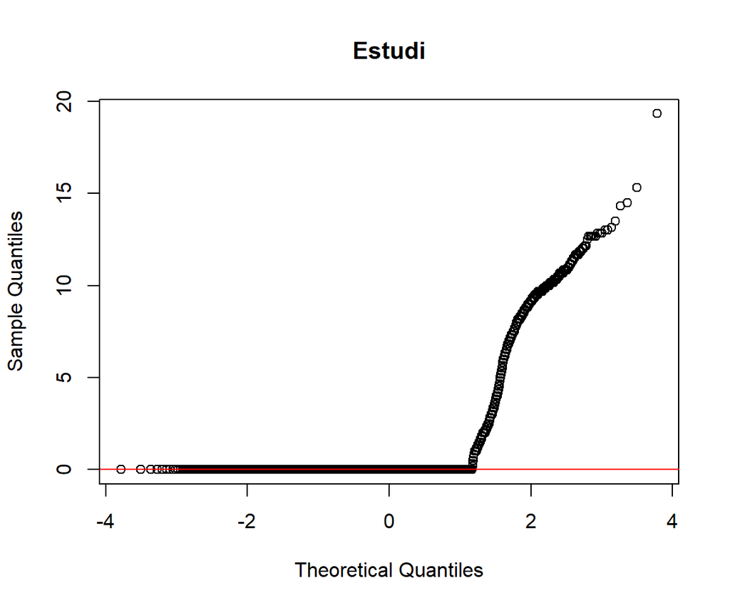

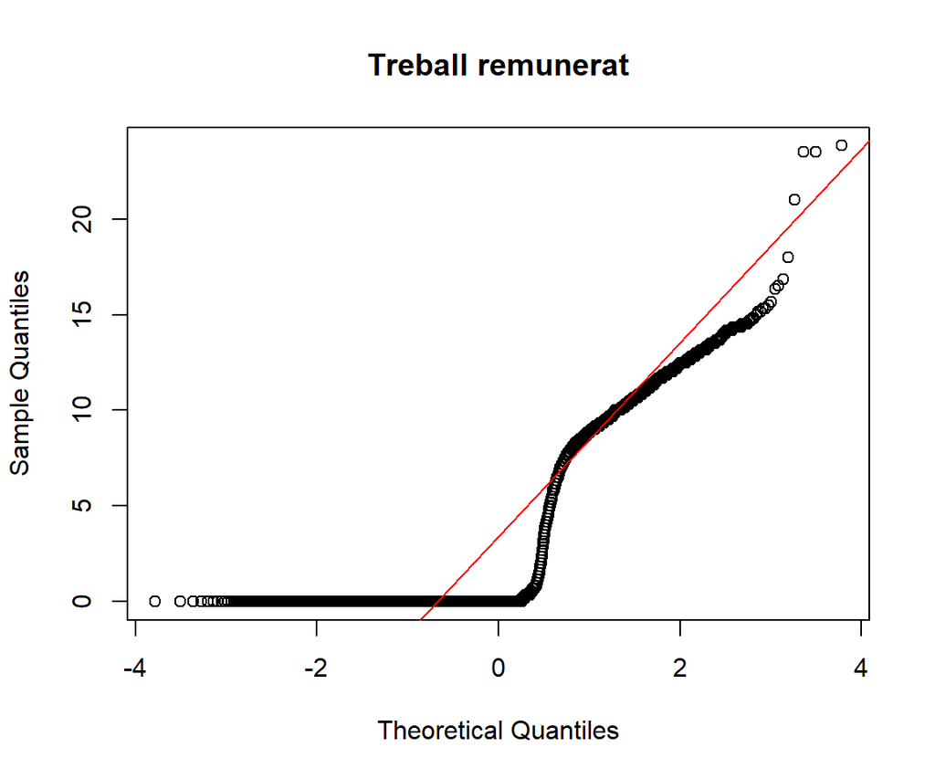

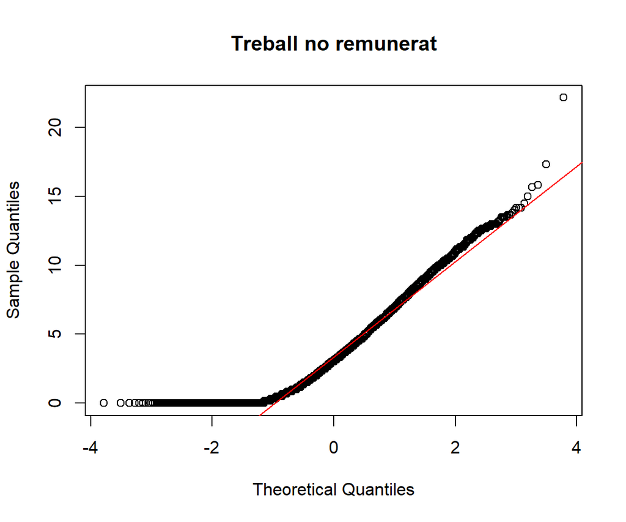

```r
walk(us_temps, ~ {
  qqnorm(dades_wide_2011[[.x]], main = .x)
  qqline(dades_wide_2011[[.x]], col = "red")
})
```

Si cap variable és gaussiana, caldrà fer servir tests no paramètrics.

#### 4.1.0.2 **1. Dues variables categòriques: test χ² i comparacions 2 a 2**

Per analitzar si dues variables categòriques (per exemple, IPT i DEGURBA) estan relacionades, s’utilitza el test χ² d’independència. Les hipòtesis són:

$$H_0: \text{Les variables són independents} \qquad
H_1: \text{Les variables no són independents}$$

Si el test χ² indica diferències significatives, es fan comparacions 2 a 2 entre els nivells del factor amb `pairwise.prop.test(..., p.adjust.method = "holm")`, que permet identificar entre quins nivells hi ha diferències de proporcions.

#### 4.1.0.3 **2. Variable contínua HORES segons una variable categòrica**

Com que les hores no segueixen una distribució normal i presenten asimetries, s’utilitza un enfocament no paramètric. Per a cada ús del temps (`US_TEMPS`):

- Amb dos grups, test de Wilcoxon (`rstatix::wilcox_test`).
- Amb més de dos grups, `ggbetweenstats`, que combina un test global de Kruskal–Wallis, comparacions post-hoc 2 a 2 (Dunn), correcció de Holm i la representació amb violí + caixa.

Les hipòtesis són:

$$H_0: \text{Les distribucions de les mostres són iguals} \qquad
H_1: \text{Les distribucions difereixen}$$

#### 4.1.0.4 **3. Gràfics de barres amb intervals de confiança**

Com a complement visual, es representen les mitjanes d’hores per grup amb intervals de confiança del 95%. Aquest enfocament és descriptiu i facilita la interpretació de les diferències entre grups.

#### 4.1.0.5 **4. Correcció de Holm**

En totes les comparacions múltiples s’aplica la correcció de Holm, que controla l’error familiar (FWER) i és menys conservadora que la de Bonferroni.

## 4.2 3.1 IPT i ús del temps

```r
taula_us_temps(dades_wide_2011, "IPT_FACTOR", "Distribució del temps segons pobresa temporal (2011)")
```

Distribució del temps segons pobresa temporal (2011)

|  | [ALL] | No pobre | Pobre | p.overall |
| --- | --- | --- | --- | --- |
|  | N=6471 | N=5024 | N=1447 |  |
| Temps disponible | 5.47 [5.39;5.55] | 6.61 [6.53;6.68] | 1.54 [1.50;1.58] | 0.000 |
| Cures personals | 11.5 [11.4;11.5] | 11.7 [11.6;11.8] | 10.6 [10.5;10.7] | <0.001 |
| Estudi | 0.64 [0.58;0.69] | 0.56 [0.51;0.62] | 0.89 [0.75;1.03] | <0.001 |
| Treball remunerat | 2.82 [2.71;2.92] | 1.67 [1.58;1.76] | 6.80 [6.55;7.05] | <0.001 |
| Treball no remunerat | 3.62 [3.55;3.70] | 3.46 [3.38;3.54] | 4.17 [3.97;4.36] | <0.001 |

La taula mostra la mitjana (i l’IC al 95%) de les hores dedicades a cada activitat, primer en tota la mostra i després estratificant per no pobres i pobres en temps. El p-valor de l’última columna contrasta si els dos grups dediquen el mateix temps a cada activitat.

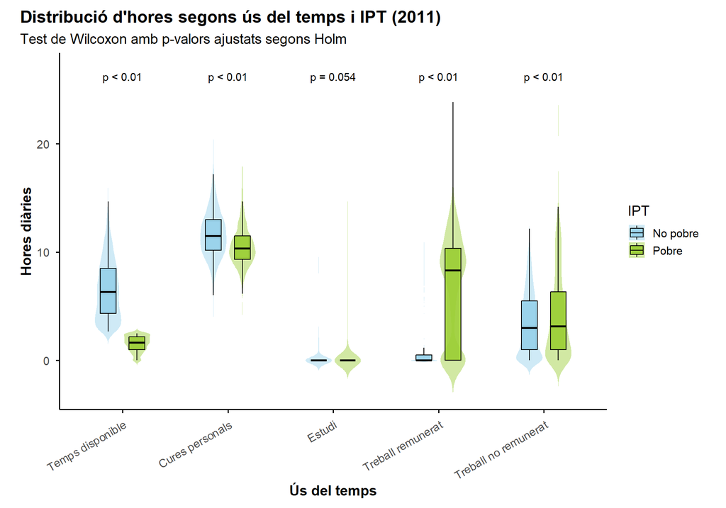

```r
mostra(plot_us_temps(dades_long_2011, "IPT_FACTOR",
                     "Distribució d'hores segons ús del temps i IPT (2011)", "IPT"),
       "us_temps_ipt_2011", 10, 7)
```

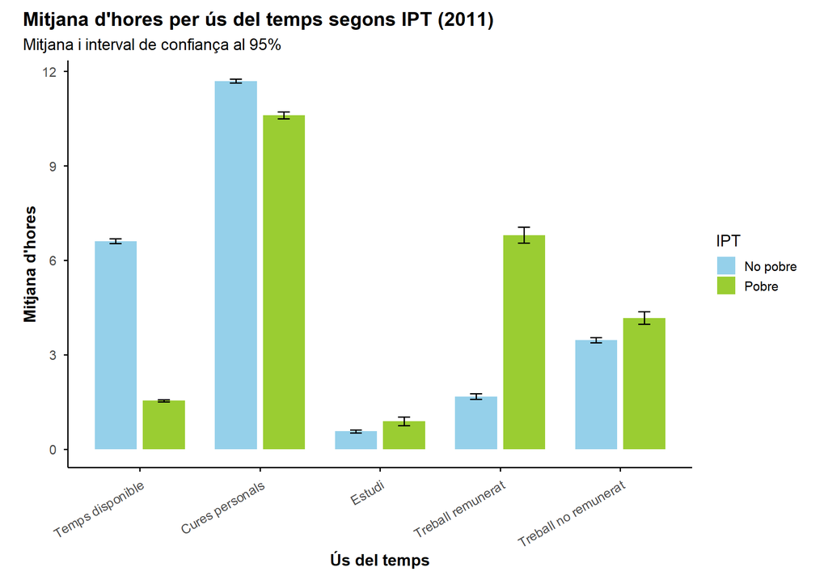

```r
mostra(plot_mitjanes(dades_long_2011, "IPT_FACTOR",
                     "Mitjana d'hores per ús del temps segons IPT (2011)", "IPT"),
       "mitjanes_ipt_2011", 10, 7)
```

El gràfic de violins i caixes mostra la distribució: la línia negra de la caixa és la mediana, els extrems de la caixa el 25% i el 75%, i l’amplada del violí la densitat d’individus.

## 4.3 3.2 Sexe

```r
taula_us_temps(dades_wide_2011, "SEXE", "Distribució del temps segons sexe (2011)")
```

Distribució del temps segons sexe (2011)

|  | [ALL] | Dona | Home | p.overall |
| --- | --- | --- | --- | --- |
|  | N=6471 | N=3420 | N=3051 |  |
| Temps disponible | 5.47 [5.39;5.55] | 5.05 [4.95;5.15] | 5.95 [5.83;6.07] | <0.001 |
| Cures personals | 11.5 [11.4;11.5] | 11.5 [11.4;11.5] | 11.4 [11.4;11.5] | 0.534 |
| Estudi | 0.64 [0.58;0.69] | 0.61 [0.54;0.68] | 0.66 [0.58;0.74] | 0.374 |
| Treball remunerat | 2.82 [2.71;2.92] | 2.27 [2.14;2.39] | 3.44 [3.27;3.60] | <0.001 |
| Treball no remunerat | 3.62 [3.55;3.70] | 4.60 [4.50;4.71] | 2.52 [2.43;2.61] | <0.001 |

### 4.3.1 3.2.1 IPT segons sexe

```r
knitr::kable(resum_ipt(dades_wide_2011, "SEXE"), caption = "Pobresa temporal segons sexe (2011)")
```

Pobresa temporal segons sexe (2011)

| Grup | N | Pobres | % pobres | IC 95% |
| --- | --- | --- | --- | --- |
| Dona | 3420 | 830 | 24.3 | [22.8, 25.7] |
| Home | 3051 | 617 | 20.2 | [18.8, 21.7] |

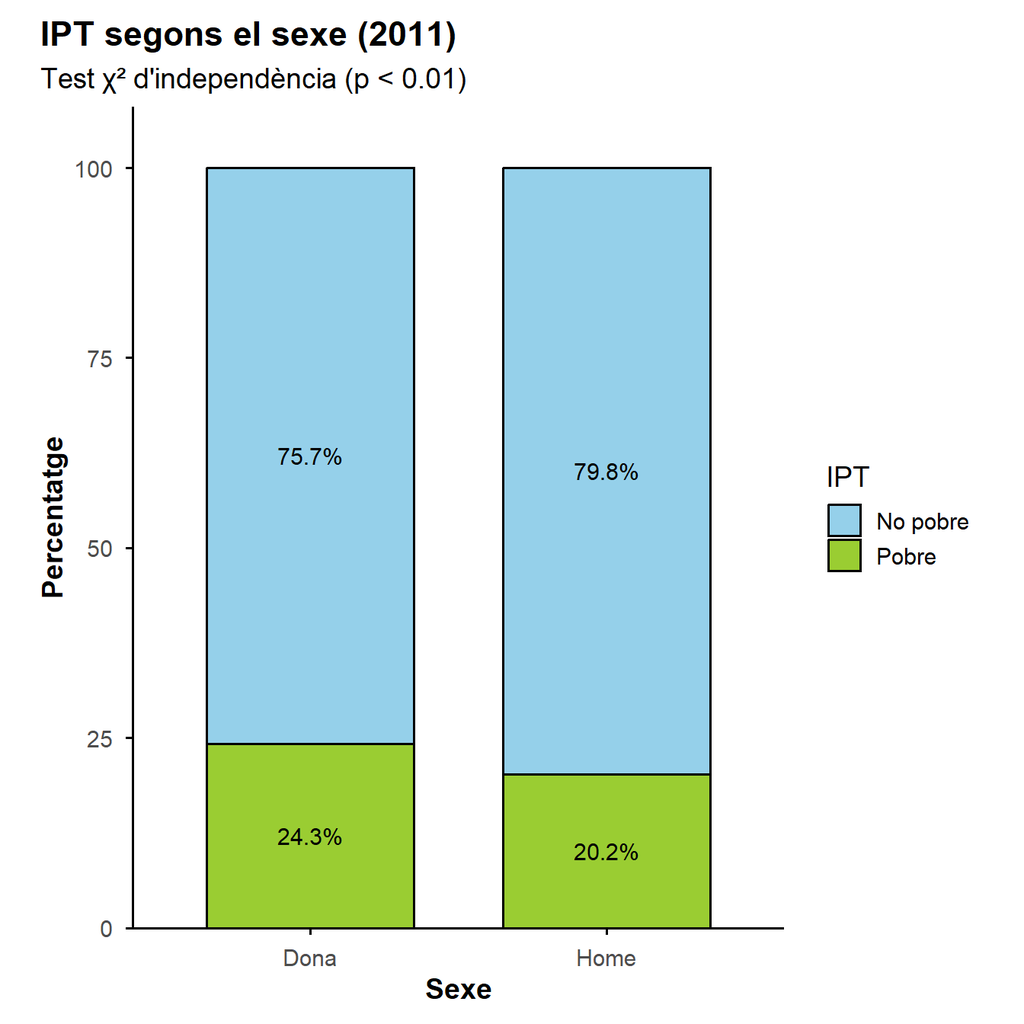

```r
mostra(plot_ipt(dades_wide_2011, "SEXE", "IPT segons el sexe (2011)", "Sexe"),
       "ipt_sexe_2011", 7, 7)
```

El test χ² d’independència dóna p < 0.01: hi ha evidència d’una associació estadísticament significativa entre la variable i la pobresa temporal.

### 4.3.2 3.2.2 Ús del temps segons sexe

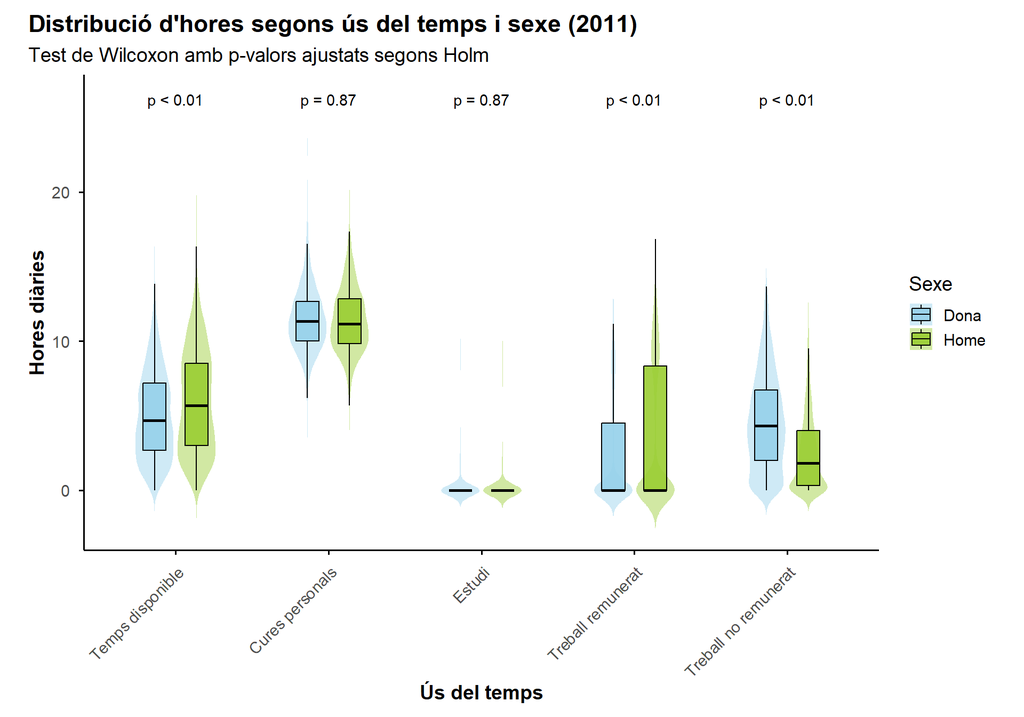

```r
mostra(plot_us_temps(dades_long_2011, "SEXE",
                     "Distribució d'hores segons ús del temps i sexe (2011)", "Sexe", angle = 45),
       "us_temps_sexe_2011", 10, 7)
```

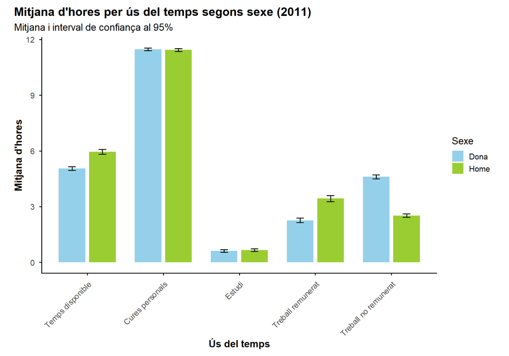

```r
mostra(plot_mitjanes(dades_long_2011, "SEXE",
                     "Mitjana d'hores per ús del temps segons sexe (2011)", "Sexe", angle = 45),
       "mitjanes_sexe_2011", 10, 7)
```

### 4.3.3 3.2.3 Sexe i IPT envers l’ús del temps

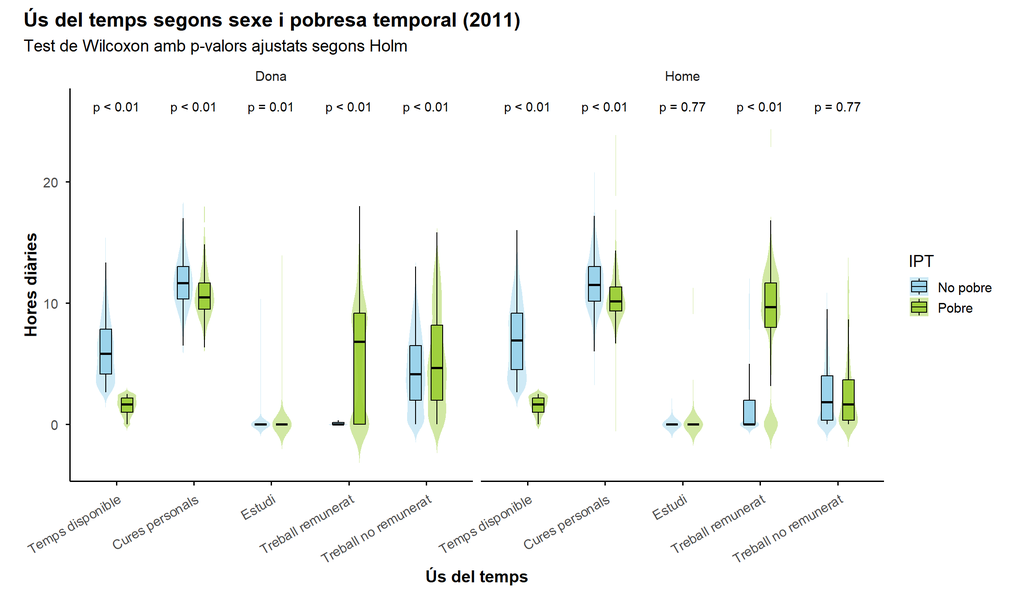

```r
mostra(plot_us_temps(dades_long_2011, "IPT_FACTOR",
                     "Ús del temps segons sexe i pobresa temporal (2011)", "IPT", facet = "SEXE"),
       "us_temps_sexe_ipt_2011", 12, 7)
```

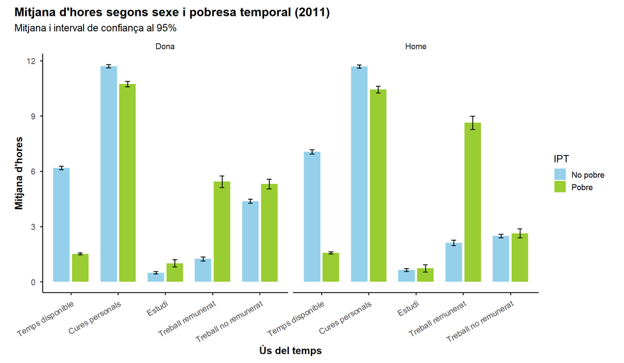

```r
mostra(plot_mitjanes(dades_long_2011, "IPT_FACTOR",
                     "Mitjana d'hores segons sexe i pobresa temporal (2011)", "IPT", facet = "SEXE"),
       "mitjanes_sexe_ipt_2011", 12, 7)
```

## 4.4 3.3 Mida del municipi (`DEGURBA`)

### 4.4.1 3.3.1 IPT segons la mida del municipi

```r
knitr::kable(resum_ipt(dades_wide_2011, "DEGURBA"), caption = "Pobresa temporal segons mida del municipi (2011)")
```

Pobresa temporal segons mida del municipi (2011)

| Grup | N | Pobres | % pobres | IC 95% |
| --- | --- | --- | --- | --- |
| -20.000 habitants | 2287 | 538 | 23.5 | [21.8, 25.3] |
| 20.000-100.000 habitants | 1798 | 434 | 24.1 | [22.2, 26.2] |
| +100.000 habitants | 2386 | 475 | 19.9 | [18.3, 21.6] |

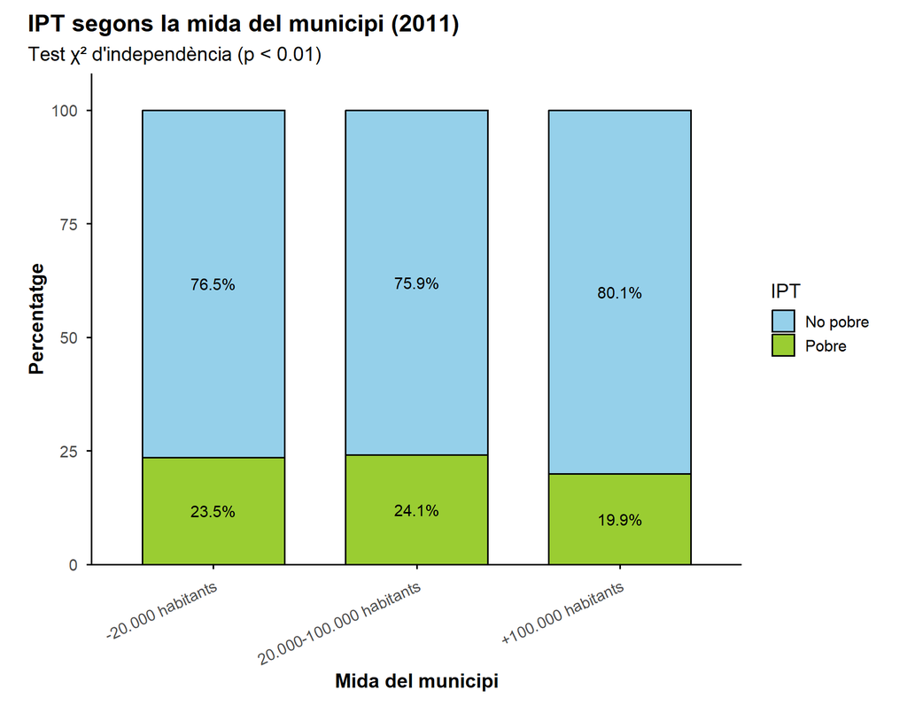

```r
mostra(plot_ipt(dades_wide_2011, "DEGURBA", "IPT segons la mida del municipi (2011)",
                "Mida del municipi", angle = 25),
       "ipt_degurba_2011", 9, 7)
```

```r
knitr::kable(pairwise_ipt(dades_wide_2011, "DEGURBA"),
             caption = "Comparacions per parelles (proporcions, ajust de Holm)")
```

Comparacions per parelles (proporcions, ajust de Holm)

| Comparació | p-valor ajustat (Holm) |
| --- | --- |
| 20.000-100.000 habitants vs -20.000 habitants | p = 0.674 |
| +100.000 habitants vs -20.000 habitants | p < 0.01 |
| +100.000 habitants vs 20.000-100.000 habitants | p < 0.01 |

El test χ² d’independència dóna p < 0.01: hi ha evidència d’una associació estadísticament significativa entre la variable i la pobresa temporal. Si el test global no és significatiu, les comparacions per parelles no són necessàries; es mostren a títol d’exemple.

### 4.4.2 3.3.2 Ús del temps segons la mida del municipi

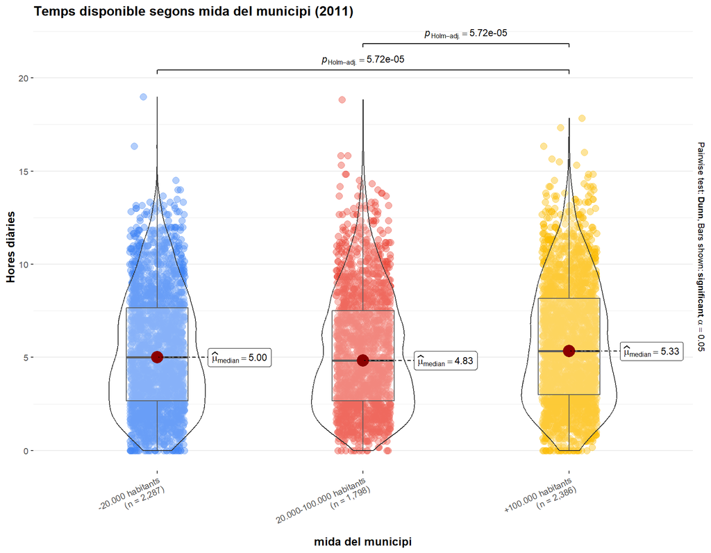

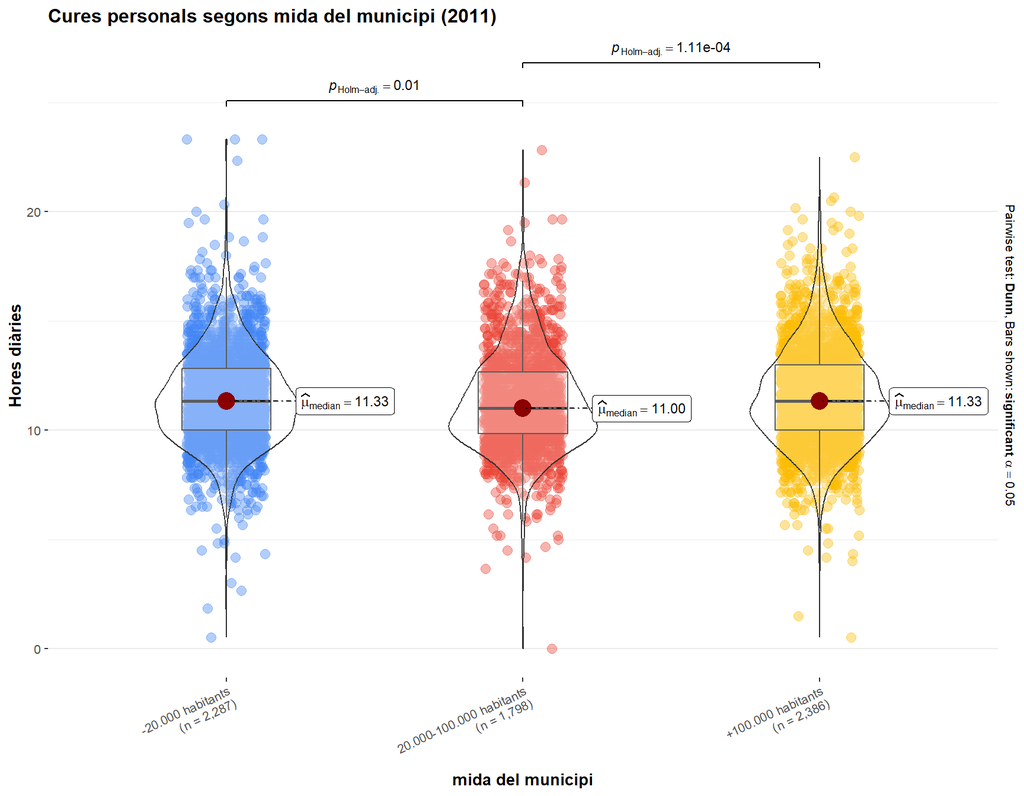

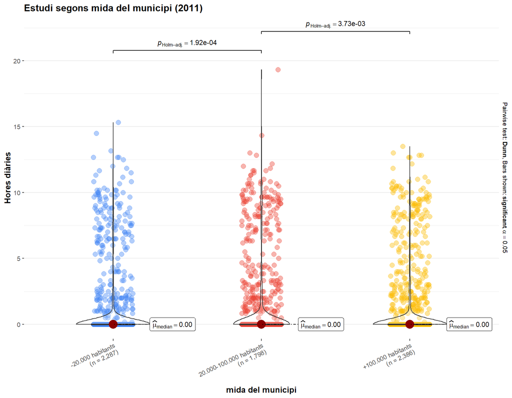

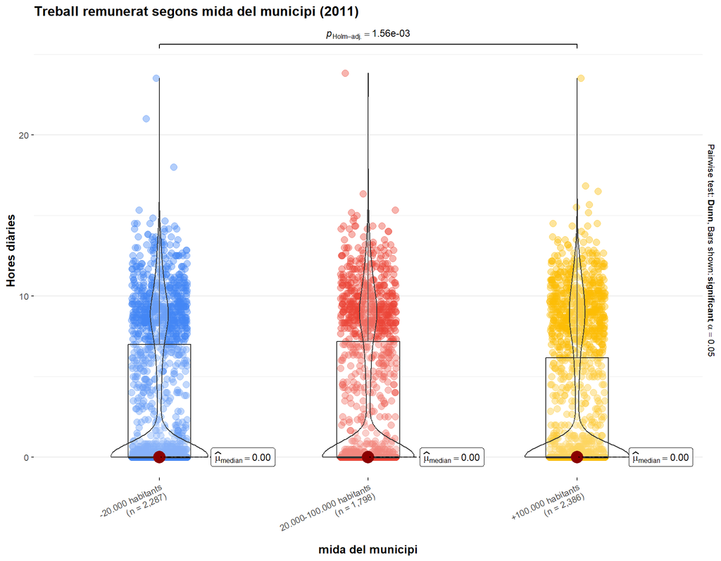

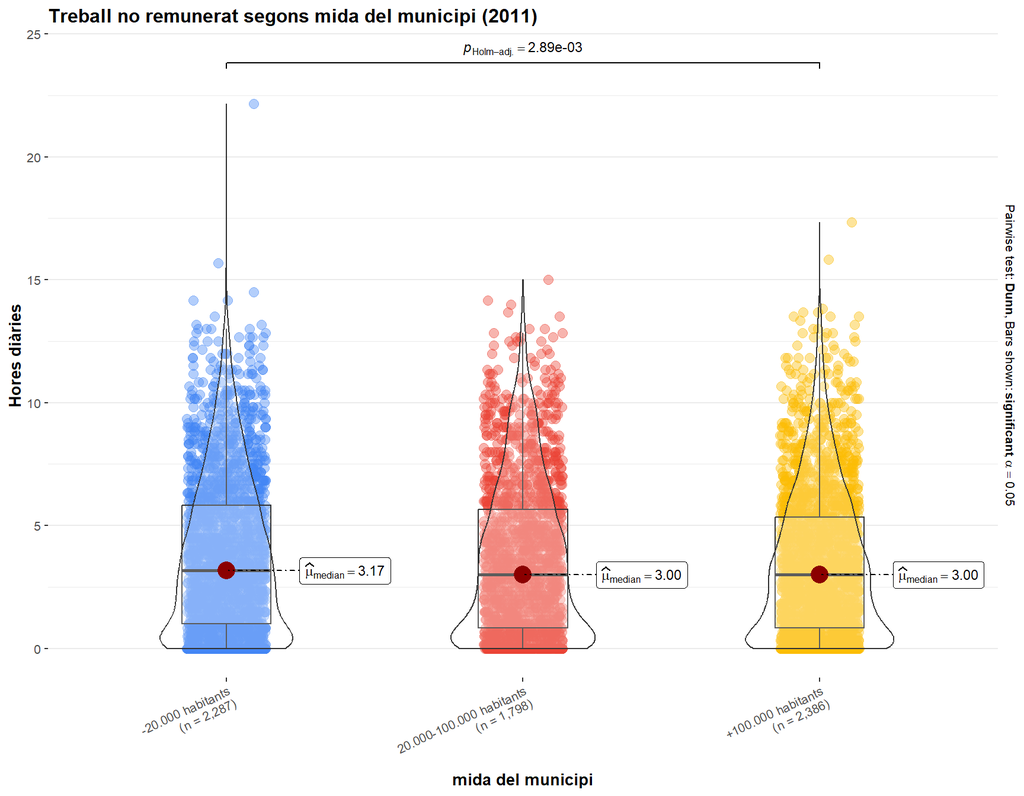

```r
walk(plots_us_temps_grups(dades_long_2011, "DEGURBA", "mida del municipi", angle = 25), print)
```

## 4.5 3.4 Nacionalitat

### 4.5.1 3.4.1 IPT segons la nacionalitat

```r
knitr::kable(resum_ipt(dades_wide_2011, "NAC"), caption = "Pobresa temporal segons nacionalitat (2011)")
```

Pobresa temporal segons nacionalitat (2011)

| Grup | N | Pobres | % pobres | IC 95% |
| --- | --- | --- | --- | --- |
| Espanyola | 5910 | 1296 | 21.9 | [20.9, 23.0] |
| Estrangera | 561 | 151 | 26.9 | [23.3, 30.8] |

[figure not shown]

```r
mostra(plot_ipt(dades_wide_2011, "NAC", "IPT segons la nacionalitat (2011)", "Nacionalitat"),
       "ipt_nac_2011")
```

El test χ² d’independència dóna p < 0.01: hi ha evidència d’una associació estadísticament significativa entre la variable i la pobresa temporal.

### 4.5.2 3.4.2 Ús del temps segons la nacionalitat

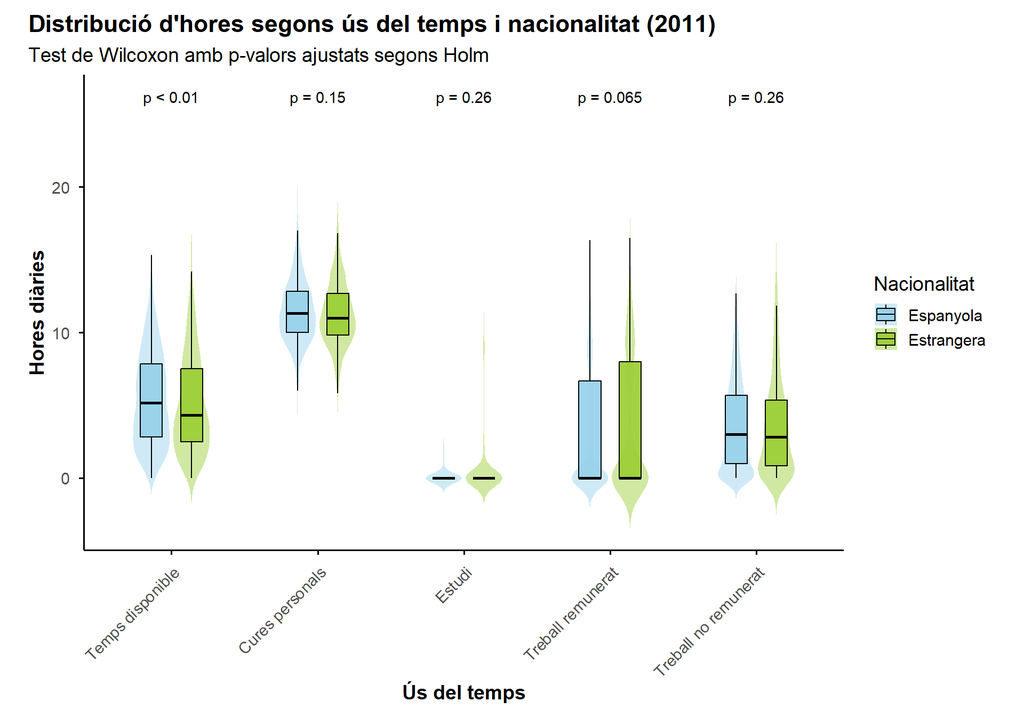

```r
mostra(plot_us_temps(dades_long_2011, "NAC",
                     "Distribució d'hores segons ús del temps i nacionalitat (2011)",
                     "Nacionalitat", angle = 45),
       "us_temps_nac_2011", 10, 7)
```

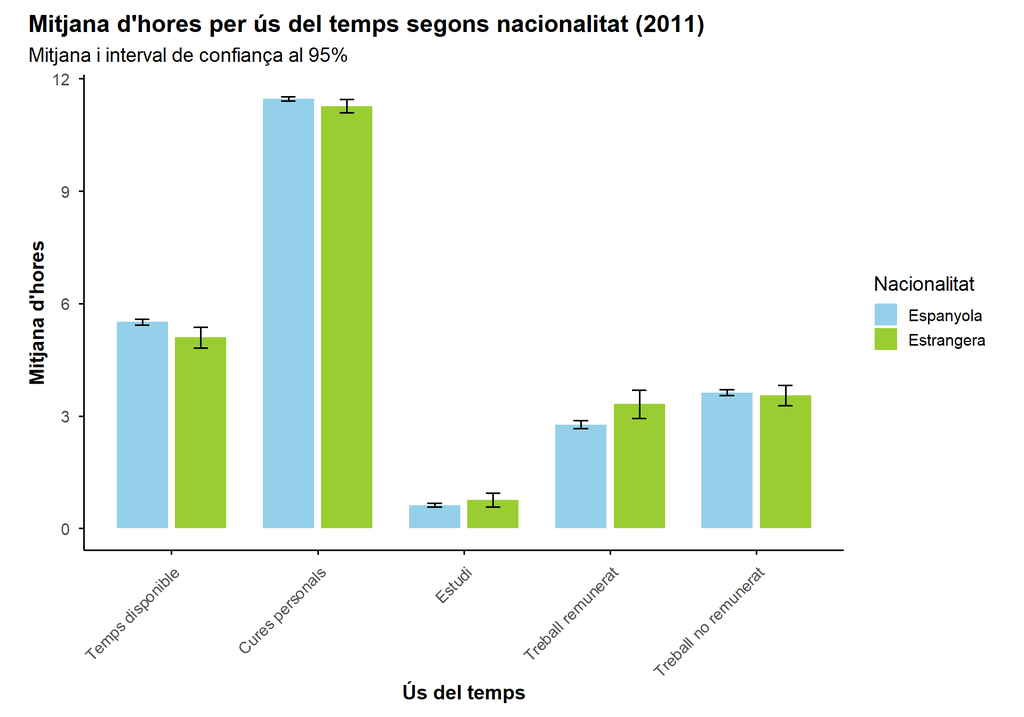

```r
mostra(plot_mitjanes(dades_long_2011, "NAC",
                     "Mitjana d'hores per ús del temps segons nacionalitat (2011)",
                     "Nacionalitat", angle = 45),
       "mitjanes_nac_2011", 10, 7)
```

## 4.6 3.5 Tipus de llar

### 4.6.1 3.5.1 IPT segons el tipus de llar

```r
knitr::kable(resum_ipt(dades_wide_2011, "TIPUS_LLAR"), caption = "Pobresa temporal segons tipus de llar (2011)")
```

Pobresa temporal segons tipus de llar (2011)

| Grup | N | Pobres | % pobres | IC 95% |
| --- | --- | --- | --- | --- |
| Parella amb fills <25 | 2707 | 774 | 28.6 | [26.9, 30.3] |
| Unipersonal | 664 | 73 | 11.0 | [8.7, 13.6] |
| Parella sense fills | 1480 | 245 | 16.6 | [14.7, 18.5] |
| Monoparental fills <25 | 292 | 69 | 23.6 | [18.9, 28.9] |
| Monoparental fills ≥25 | 196 | 36 | 18.4 | [13.2, 24.5] |
| Parella amb fills ≥25 | 532 | 101 | 19.0 | [15.7, 22.6] |
| Altres | 600 | 149 | 24.8 | [21.4, 28.5] |

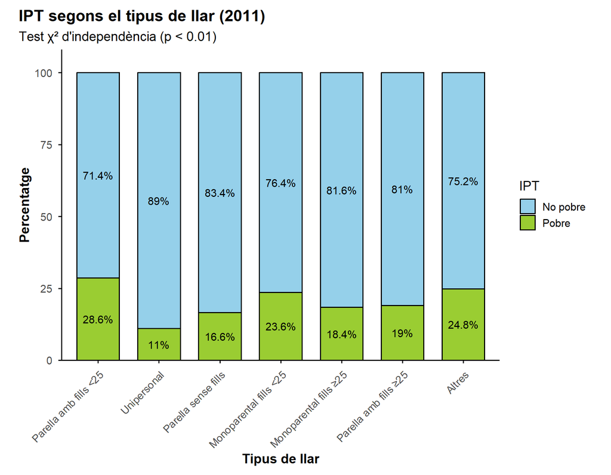

```r
mostra(plot_ipt(dades_wide_2011, "TIPUS_LLAR", "IPT segons el tipus de llar (2011)",
                "Tipus de llar", angle = 45),
       "ipt_tipus_llar_2011", 9, 7)
```

```r
datatable(pairwise_ipt(dades_wide_2011, "TIPUS_LLAR"), rownames = FALSE,
          caption = "Comparacions per parelles (proporcions, ajust de Holm)",
          options = list(pageLength = 10))
```

| Comparació | p-valor ajustat (Holm) |
| --- | --- |
| Unipersonal vs Parella amb fills &lt;25 | p &lt; 0.01 |
| Parella sense fills vs Parella amb fills &lt;25 | p &lt; 0.01 |
| Parella sense fills vs Unipersonal | p = 0.0144 |
| Monoparental fills &lt;25 vs Parella amb fills &lt;25 | p = 0.637 |
| Monoparental fills &lt;25 vs Unipersonal | p &lt; 0.01 |
| Monoparental fills &lt;25 vs Parella sense fills | p = 0.0594 |
| Monoparental fills ≥25 vs Parella amb fills &lt;25 | p = 0.0351 |
| Monoparental fills ≥25 vs Unipersonal | p = 0.101 |
| Monoparental fills ≥25 vs Parella sense fills | p = 1 |
| Monoparental fills ≥25 vs Monoparental fills &lt;25 | p = 1 |

[output cut: 11 more lines]

El test χ² d’independència dóna p < 0.01: hi ha evidència d’una associació estadísticament significativa entre la variable i la pobresa temporal.

### 4.6.2 3.5.2 Ús del temps segons el tipus de llar

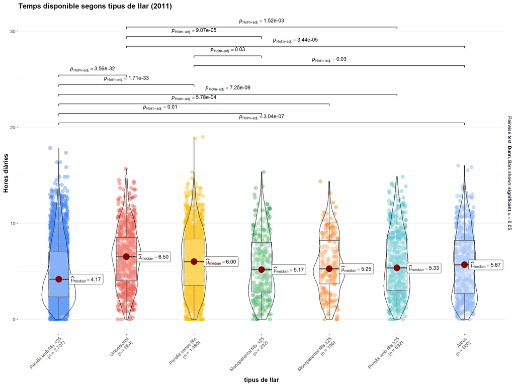

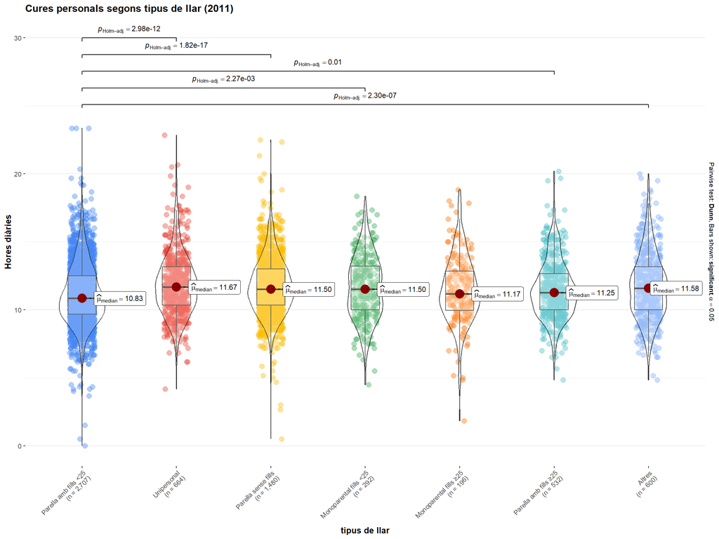

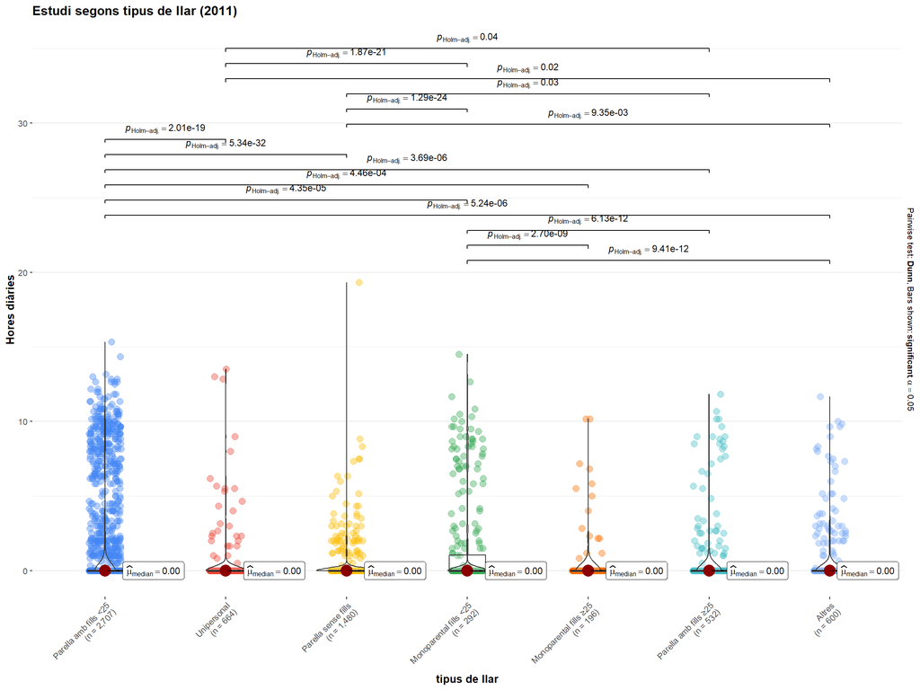

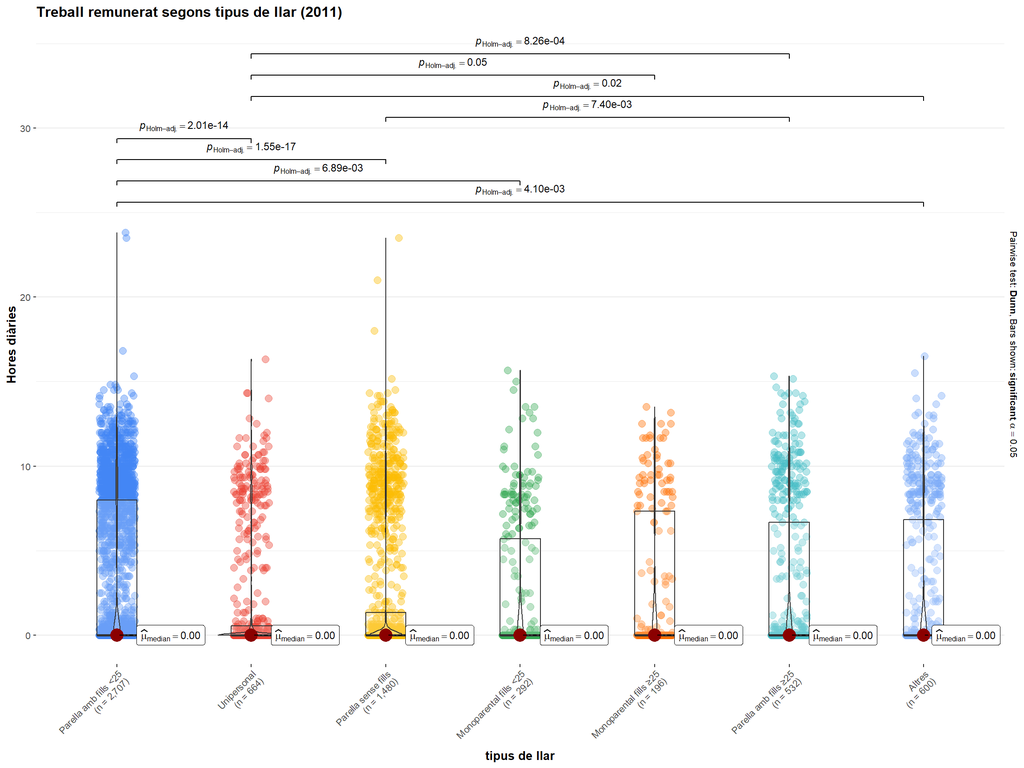

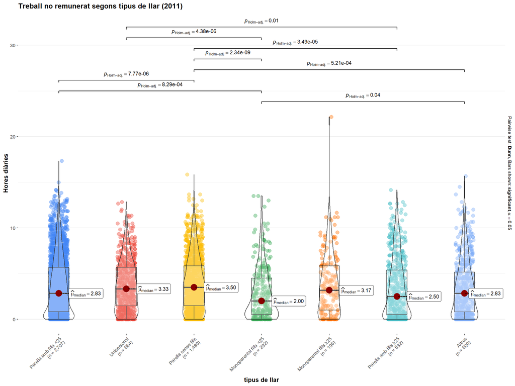

```r
walk(plots_us_temps_grups(dades_long_2011, "TIPUS_LLAR", "tipus de llar"), print)
```

## 4.7 3.6 Tram d’ingressos

### 4.7.1 3.6.1 IPT segons el tram d’ingressos

```r
knitr::kable(resum_ipt(dades_wide_2011, "TRAM_INGRESSOS"), caption = "Pobresa temporal segons tram d'ingressos (2011)")
```

Pobresa temporal segons tram d’ingressos (2011)

| Grup | N | Pobres | % pobres | IC 95% |
| --- | --- | --- | --- | --- |
| 700 € o menys | 417 | 40 | 9.6 | [6.9, 12.8] |
| De 701 € a 1.000 € | 468 | 65 | 13.9 | [10.9, 17.4] |
| De 1.001 € a 1.400 € | 676 | 121 | 17.9 | [15.1, 21.0] |
| De 1.401 € a 1.700 € | 504 | 114 | 22.6 | [19.0, 26.5] |
| De 1.701 € a 2.000 € | 460 | 107 | 23.3 | [19.5, 27.4] |
| De 2.001 € a 2.300 € | 398 | 90 | 22.6 | [18.6, 27.0] |
| De 2.301 € a 2.600 € | 389 | 113 | 29.0 | [24.6, 33.8] |
| De 2.601 € a 3.100 € | 446 | 133 | 29.8 | [25.6, 34.3] |
| De 3.101 € a 4.000 € | 441 | 138 | 31.3 | [27.0, 35.8] |
| Més de 4.000 € | 398 | 113 | 28.4 | [24.0, 33.1] |

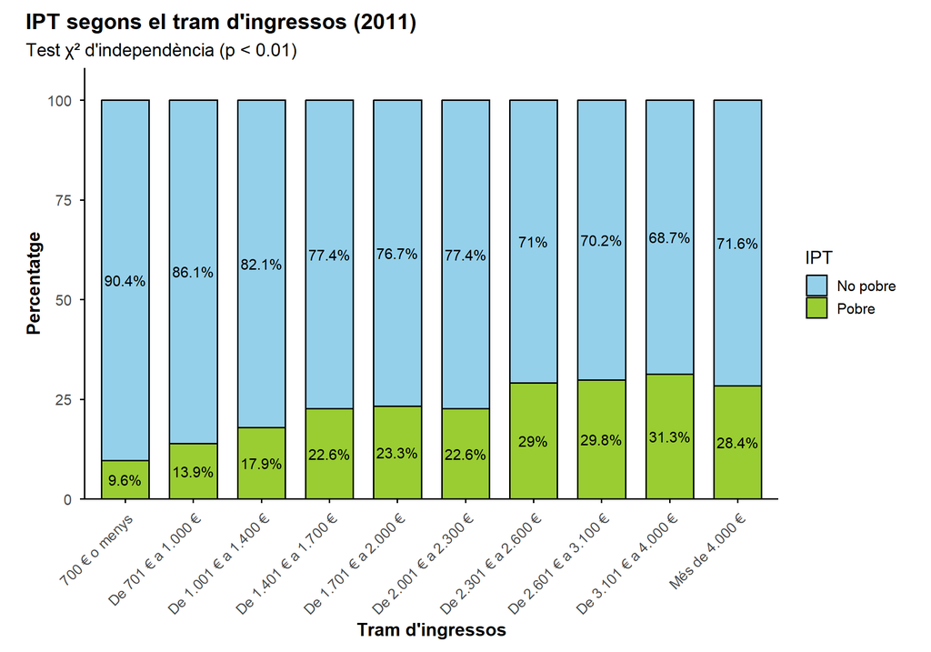

```r
mostra(plot_ipt(dades_wide_2011, "TRAM_INGRESSOS", "IPT segons el tram d'ingressos (2011)",
                "Tram d'ingressos", angle = 45),
       "ipt_tram_ingressos_2011", 10, 7)
```

```r
datatable(pairwise_ipt(dades_wide_2011, "TRAM_INGRESSOS"), rownames = FALSE,
          caption = "Comparacions per parelles (proporcions, ajust de Holm)",
          options = list(pageLength = 10))
```

| Comparació | p-valor ajustat (Holm) |
| --- | --- |
| De 701 € a 1.000 € vs 700 € o menys | p = 0.924 |
| De 1.001 € a 1.400 € vs 700 € o menys | p &lt; 0.01 |
| De 1.001 € a 1.400 € vs De 701 € a 1.000 € | p = 0.938 |
| De 1.401 € a 1.700 € vs 700 € o menys | p &lt; 0.01 |
| De 1.401 € a 1.700 € vs De 701 € a 1.000 € | p = 0.0172 |
| De 1.401 € a 1.700 € vs De 1.001 € a 1.400 € | p = 0.902 |
| De 1.701 € a 2.000 € vs 700 € o menys | p &lt; 0.01 |
| De 1.701 € a 2.000 € vs De 701 € a 1.000 € | p &lt; 0.01 |
| De 1.701 € a 2.000 € vs De 1.001 € a 1.400 € | p = 0.648 |
| De 1.701 € a 2.000 € vs De 1.401 € a 1.700 € | p = 1 |

[output cut: 35 more lines]

El test χ² d’independència dóna p < 0.01: hi ha evidència d’una associació estadísticament significativa entre la variable i la pobresa temporal.